# O Método Científico

Aplicações à Area de Ciências Sociais

Alexandre Nicolella

nicolella@usp.br

Universidade de São Paulo - Depto Economia/RP

2026-10-22

# O Método Ciêntífico

# A Ciência no Dia a Dia

## Notícias

- A ciência está presente em muitos aspectos do nosso dia a dia

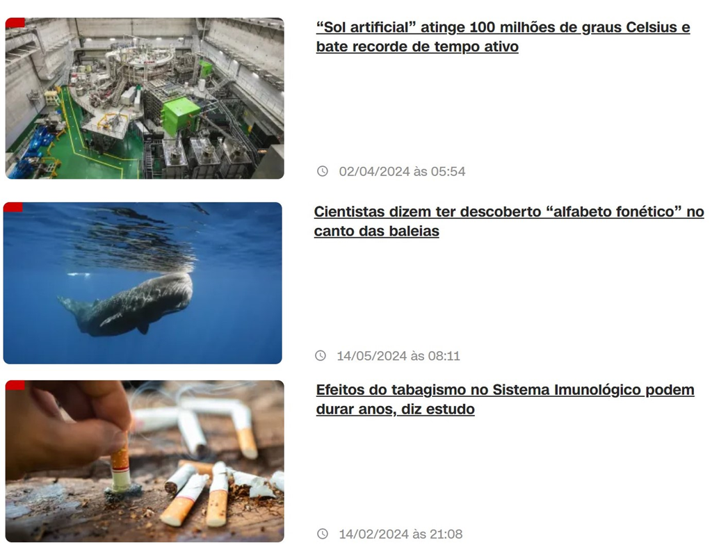

Ciência no dia a dia

## Um Experimento Importante

### Observações Iniciais: Mortes no Mar

- Em longas viagens oceânicas (Séc XVIII), marinheiros adoeciam e morriam em grandes números.
- Hipóteses iniciais: “ar ruim” e condições adversas como as causas (Teoria Miasmática).
- Qual a verdadeira causa e quais as soluções?

## O Experimento de James Lind (1747)

- James Lind, médico naval britânico, foi pioneiro no uso de experimentos controlados.
- Em 1747, testou diferentes tratamentos em marinheiros com escorbuto a bordo do HMS Salisbury.
- Dividiu os marinheiros em grupos, cada um recebendo um tratamento diferente (vinagre, água do mar, cidra, etc.).
- Apenas o grupo que recebeu limões e laranjas se recuperou.

## A Descoberta Revolucionária

### Cura do Escorbuto

- Observação: os marinheiros que consumiram frutas cítricas melhoraram rapidamente.
- Descoberta: A deficiência de algum “nutriente” presente nos cítricos era a causa do escorbuto.
- Conclusão: A ingestão regular de frutas cítricas poderia prevenir a doença.

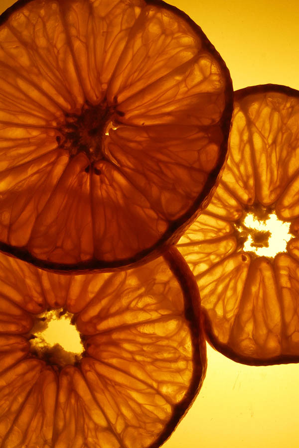

## O Impacto

### Salvando Vidas no Mar

- Após o experimento de Lind, a Marinha Britânica adotou a prática de fornecer frutas cítricas aos marinheiros.
- Redução significativa nas mortes por escorbuto em viagens longas.
- O primeiro experimento controlado de Lind foi fundamental para entender a importância da vitamina C.

[figure not shown]

Imagem de James Lind

# A Ciência

## Perguntado “Por que”

- Porque as coisas acontecem da forma como ocorreram.
- Ciência é a atividade que tem o objetivo de ampliar o nosso conhecimento sobre o porque as coisas acontecem e da forma como ocorreram
- Voltando a medicina até metade do século 19th pouco se sabia sobre doenças infecciosas e suas transmissões (Pasteur 1822 a 1895).

## Perguntado “Por que”

- Tábuas de Mortalidade.
- Em 1662 John Graunt publicou a primeira tábua de mortalidade.
  - Livro: Natural and Political Observations Made upon the Bills of Mortality(1662)
- Pasteur consolidou a Teoria Microbiana da Doença e criou o processo conhecido com Pasteurização.
- Em 1873 na academia de Medicina Francesa defende a tese que doenças contagiosas e processos infecciosos tem os microrganismos como responsáveis.

[figure not shown]

Uma das Primeiras Tábuas de Mortalidade

# Mais um Exemplo

Ignaz Semmelweis: O Pai da Higiene Hospitalar

## Quem foi Ignaz Semmelweis?

- Médico húngaro nascido em 1818.
- Trabalhou no Hospital Geral de Viena no século XIX.
- Conhecido por suas contribuições na redução da mortalidade materna.

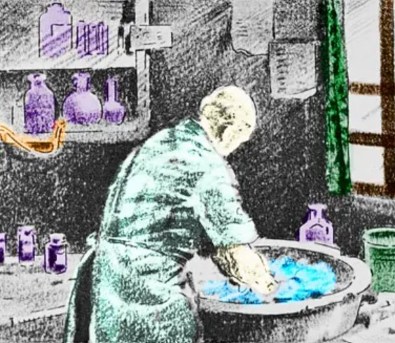

Contribuição de Ignaz. Fonte: BBC

## Observação Inicial

- Alta taxa de mortalidade por febre puerperal (infecção pós-parto).
- Semmelweis notou que mulheres que davam à luz na ala médica tinham taxas de mortalidade muito mais altas do que aquelas na ala de parteiras.

## A Grande Descoberta

- Um colega que trabalhava em uma autópsia se cortou e morreu com sintomas parecidos com os da febre puerperal.
- Semmelweis observou que médicos realizavam autópsias e, sem lavar as mãos, atendiam parturientes.
- **Hipótese**: Que a matéria cadavélica poderia ser a causa da febre puerperal.
- **Teste**: Sugeriu a lavagem das mãos com uma solução de cloro antes de tocar em pacientes.

[figure not shown]

## Resultados

- **Redução drástica na taxa de mortalidade por febre puerperal**.
  - A introdução da lavagem das mãos reduziu drasticamente as mortes por febre puerperal.
  - De 18% de mortalidade para menos de 2% nas enfermarias.
- **O Choque da Comunidade Médica**
  - Apesar dos resultados, suas ideias foram amplamente rejeitadas por seus pares.
  - Somente anos depois, com o avanço da teoria germinal das doenças, Semmelweis foi reconhecido.

# Método Científico

Observar, Explicar e Testar

## 1. Observar

- Noção clara dos fatos que envolvem o fenômeno que estamos investigando.

**Observação Cuidadosa**

A explicação de Semmelweis sobre a febre puerperal foi motivada por inúmeros fatos, todos produtos de observação cuidadosa.

- Taxas de febre puerperal diferiam nas enfermarias.
- Taxa mais alta nas alas tratadas por médicos
- Sintomas similares de seu colega que estava morrendo.

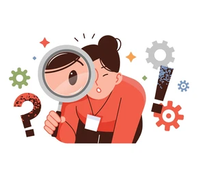

## 2.Propor Explicação

- Explicar algo é introduzir um conjunto de fatores que explicam como ou por que o efeito observado foi o caso.
- Por que, por exemplo, o sol nasce e se põe diariamente?

**História Explicativa**

Portanto, a primeira etapa na tentativa de dar sentido a um conjunto de fatos intrigantes é propor o que poderíamos chamar de uma história explicativa, um conjunto de conjecturas que, se verdadeiras, explicariam o quebra-cabeça.

## Testar Explicação

**Como testar se uma explicação proposta está correta?**

- Primeiro observa-se as consequências da explicação.
  - O que aconteceria se a explicação estivesse na direção correta?
- Depois se propõe um desenho do experimento.
  - Se obtemos os resultados preditos -> direção correta, caso não revisar.

**Fácil Falar Difícil Fazer**

Apesar da ideia simples do método científico, a implementação é bem mais difícil.

[figure not shown]

## Objetivo da Ciência

- Ciência: Tornar o mundo um lugar melhor para vivermos pela inovação tecnológica.
- A teoria é importante:
  - A teoria é o que nos permite explicar o mundo.
  - Inovações técnicas surgem do entendimento teórico.

## Método cientifico no dia a dia

- O método científico é o tipo de solução que utilizamos no dia a dia.
- Imagine que nas últimas semanas você não tenha dormido bem, pouco e acordou muitas vezes. Isso não é normal.
  - **Questão**: Porque não estou dormindo bem?
  - **Teorias**: Você teve que estudar para um exame que ira ocorrer na semana que vem até tarde.
    - Entretanto, não é a primeira vez que estuda para o exame e nunca teve esse problema.
    - Estava muito calor e você tomou um cha gelado que tem cafeína durante os estudos. Será que pode ter sido ele?
  - **Teste**: Trocar o chá gelado por água gelada e ver se isso melhora o sono.
    - Se começar a dormir bem, existe uma chance da sua teoria estar certa.

## O Uso Inadequado da Ciência

**Credibilidade Fake**

Nada pode fazer mais para dar um ar de credibilidade a uma reivindicação do que o sugestão de que foi “comprovado em estudos científicos” ou que é “apoiado por evidência científica”.

- As pessoas afirmam, por exemplo, ter evidências científicas sólidas que extraterrestres visitaram a Terra
- Que as plantas podem experimentar prazer e dor
- Que os celulares causam tumores cerebrais,
- Que os EUA governo participou ativamente nos trágicos ataques de 11 de Setembro e agora conspira para encobrir seu papel.

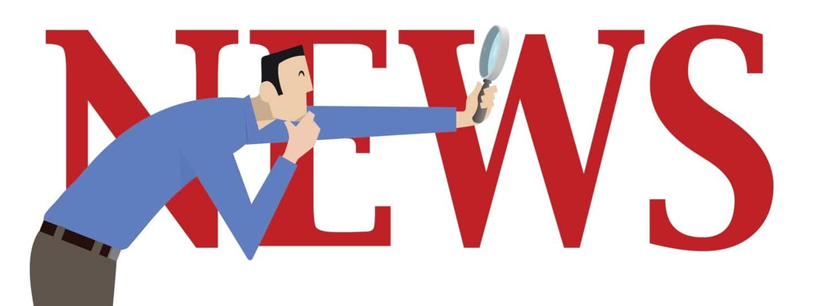

# Vamos Pensar

Obsedidade no Brasil

## Exercício

**Fatos e Observações**

Os brasileiros têm um sério problema de peso. Entre 2006 e 2019, o número de brasileiros que estão acima do peso e ou clinicamente obesos aumentou em 72%. Em 2019 o número de pessoas obesas foi de 20%.

- Vamos montar uma ou mais explicações para o fenômeno abaixo. Não precisa estar correta, mas deve explicar o fenômeno, caso seja verdadeira.

# OBSERVAÇÃO

## Introdução: Fazendo observações precisas

- Ciência é a arte de fazer boas observações
- Observações possibilitam identificar e focar nos fatos relevantes do fenômeno
- A observação pode dar pistas do porque o fenômeno acontece.
- Os dados observacionais podem dar evidências para saber se diversas explicações podem ter sucesso ou falhar.
- Nem sempre a observação é simples ou direta.
  - Nem sempre sabemos qual dados são relevantes ao problema
  - Muitas vezes é difícil coletar.

# Exercício

Objetos ao nosso redor

## Exercício

**Objetos ao nosso redor**

Vamos medir a quantidade de objetos que estão próximos dos alunos e professores dessa aula.

- Antes de começar, temos uma série de questões…

[figure not shown]

## As Questões

- O que podemos classificar como um objeto?
  - Livro? Marcador de livro? O postit? O quadro? O prego que segura o quadro?
- O que queremos dizer com próximos?
  - Ao alcance da mão? A uma distância de 10 metros? No espaço físico fechado que está?

# Fazendo Observações Acuradas

## Relevante

Para observações acuradas :

1. **Ter clara noção de quais os fenômenos relevantes**
- Os fumantes possuem maiores taxas de doenças cardiovasculares que os não fumantes?
  - O que significa fumantes de cigarros? E os que pararam de fumar recentemente? Quem já fumou alguma vez? Quantos cigarros por semana/mês?

## Cuidadosa

Para observações acuradas:

2. **Encontramos uma maneira de garantir que não negligenciamos nada no processo de fazer nossas observações?**
- Pense na cena de um crime o que estamos deixando passar que pode ser importante?

**Exemplo**

Willian James (1882) observa que muitos passageiros em uma viagem marítima ficavam doente/enjoados.

- **Observação**: 15 deles não ficaram enjoados e eram surdos e mudos.
- **Hipótese**: Pode ser fruto de um distúrbio temporário da parte interna do ouvido. Viu algo que os outros não viram….

## Cuidado com os Viéses

Tendemos a ignorar muitos fatos importantes:

- *Cegueira a mudança*.
  - Exemplo: Foto de paris onde o carro ao fundo muda de cor. Muitos falham em notar essa mudança. https://www.youtube.com/watch?v=FaAIW8WFBq8
- *Cegueira desatenta*:
  - Exemplo: Experimento que time de basquete que passa a bola e você tem que contar o número de passes. Entre os passos uma pessoa vestido de macaco entra e bate no peito e sai. Ao perguntar se houve algo não usual, poucos respondem que sim.

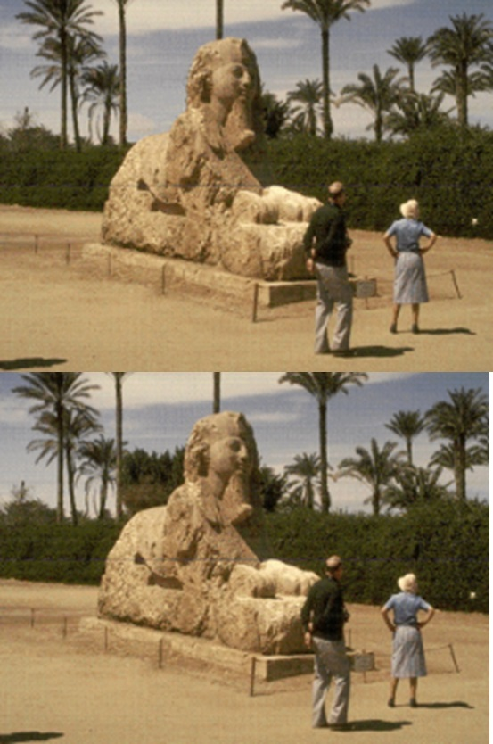

## Baseada em Fatos

Para observações acuradas:

3. **O que sabemos com certeza? O que é baseado em fatos e o que é baseado em conjecturas ou suposição?**

**Exemplo**

A Lua é maior quando ela está no horizonte? É um fato?

- **Teste**. Estique o braço e meça a lua com o seu dedão quando ela estiver no horizonte, faça o mesmo quando ela estiver no alto. Verá que o diâmetro é igual.

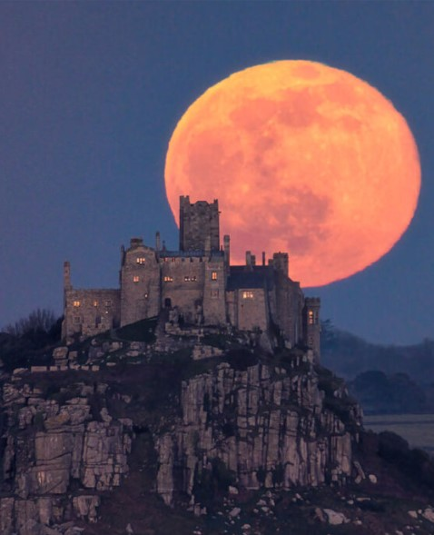

## Sempre pergunte:

- O que eu realmente sei sobre os fenômenos sob investigação e o que estou assumindo com base no que me disseram ou ouvi, li, etc.?
- Separando a Ficção do Fato:

**Importante**

Gaste tempo de observação e veja o que realmente está acontecendo, em vez de confiar implicitamente em suposições trazidas para investigação.

## Suposições inocentemente incorporadas

- Suposições que são incorporadas em nossas observações:
  - “Você parou de beber?” Qualquer uma das respostas pressupõe que você bebia.
- Perguntas “como” e “por que” pode nos tentar a aceitar como verdade aquilo que nos pedem para explicar.
  - “Como a telepatia mental funciona?”

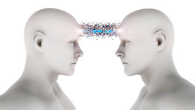

## Comparação Adequada

Para observações acuradas:

4. **Consideramos alguma informação comparativa necessária?**

**Exemplos**

- **Afirmativa**: Casais aparentemente inférteis, ao adotar uma criança, frequentemente dão a luz a um filho
- Aqui devemos fazer comparações ao longo de alguns anos e entre grupos ver o fenômeno.
- **Análise**: Com o comparartivo correto, não há diferença nas taxas de nascimento de quem adota e de quem não adota.

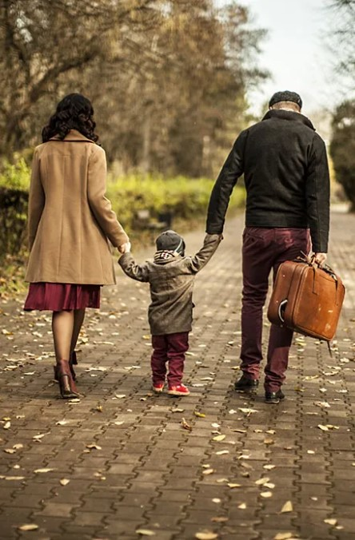

## Contaminação

Para observações acuradas:

5. **As nossas observações foram contaminadas por expectativas ou crenças?**
- Nossas experiências são coloridas pelas nossas crenças e expectativas.
- Quando a experiência é processada através do filtro da crença e expectativa, podem distorcer o que observamos.
- A tendência de focar seletivamente.
  - **Víes de Confirmação**: Basear-se em evidências que apoiam nossas crenças e rejeitamos evidências que as refutam

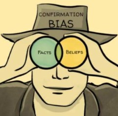

## Corrigindo crenças e expectativas:

- Uso de instrumentos para aguçar e complementar os sentidos e
- Uso de medidas quantitativas para descrever e registrar observações.

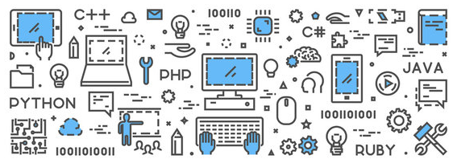

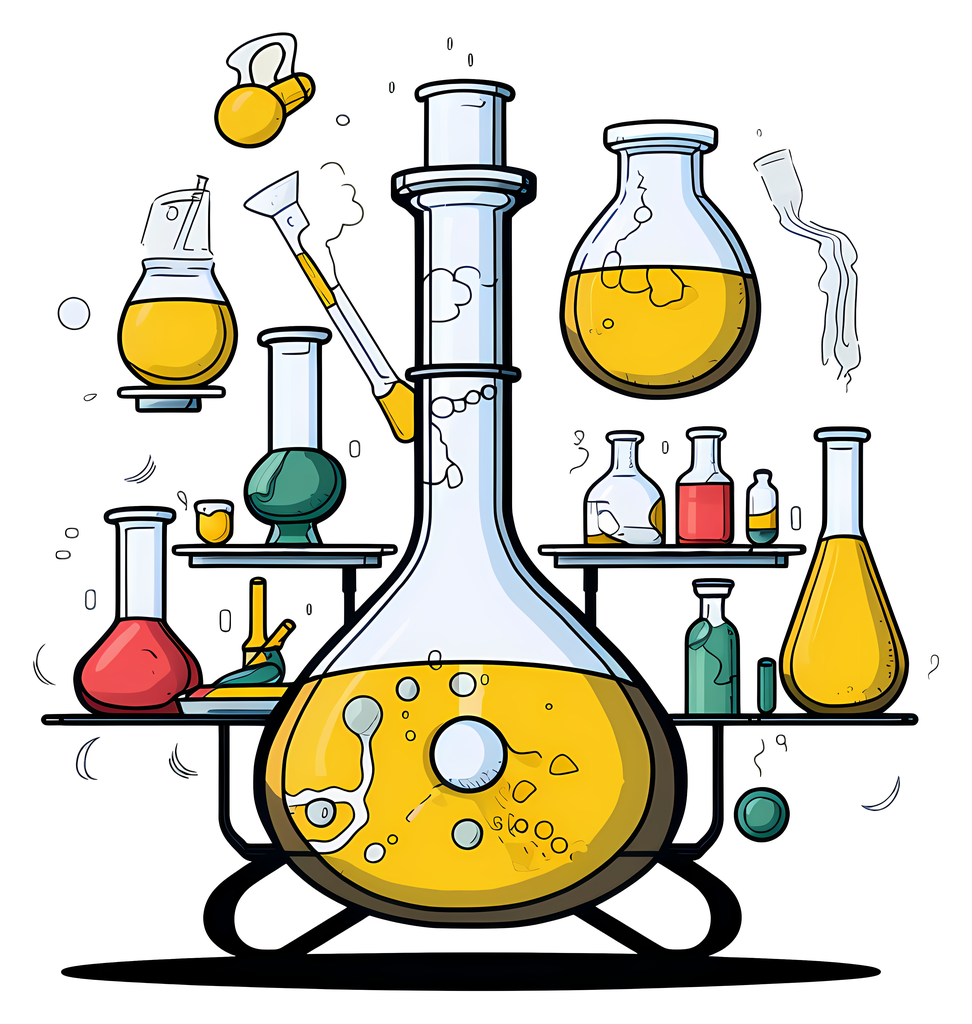

# Encontrando Boas Explicações

## Teoria e Hipótese: Explicação Científica

- **Hipótese**:
  - É um relato, embora especulativo, de como ou por que algo aconteceu.
  - É provisória e não comprovada.
  - Oferece uma explicação para um gama mais limitada de fenômenos - um único evento ou um fato.

## Teoria e Hipótese: Explicação Científica

- **Teoria**:
  - Uma teoria é um corpo bem desenvolvido e bem confirmado de um material explicativo,
    - Teoria do big bang,
    - Teoria da evolução,
    - Teoria dos germes da doença.

**Importante**

Muitas vezes ouvimos: - **“Isso é apenas uma teoria”**

- Como se fosse uma opinião.

## Teoria e Hipótese: Explicação Científica

- **Teoria**:
  - O que tipifica as teorias na ciência é a amplitude e a profundidade de seu poder explicativo.
  - As teorias tendem a ser mais gerais, estruturadas e capazes de explicar uma variedade muito maior de fenômenos.
  - Conterão regras e princípios bem confirmados que revelam
    - Teoria Newtoniana: Explica qualquer coisa com massa…

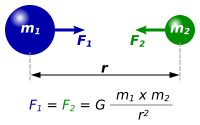

# A Causalidade

## Causalidade

- Uma maneira de explicar como ou por que algo ocorreu é dar um relato dos eventos que levaram a isso.
- Apesar de causalidade ser comum no dia a dia, a relação causal nem sempre é direta e simples.
- Vejamos algumas complexidades:

## Complexidades da Causalidade

1. Pode ser fruto de uma combinação de causas. Alergia causada pela combinação de duas fonte, leite e ovo juntos, isoladamente não.
2. Pode ser sobre grupo e não indivíduo. Fumar cigarro causar câncer no grupo de indivíduos, pois aumenta a frequência
3. Os efeitos são resultados de múltiplas causas. Cigarro, amianto, anomalias genéticas, poluição das cidades….podem causar câncer.
4. O efeito não precisa estar invariavelmente conectado ao fator causal. Muitas pessoas que fumam não vão contrair ou morrer de câncer.
5. Pode conter uma sequencia de links, A->B->C

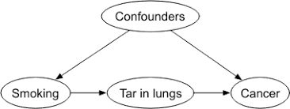

## Mecanismo causal

- Nos fornece a sequencia da causa:
- Fumar cigarro causa câncer. Estamos confidentes da relação causal.

**Questão**

Qual a substância carcinogênica que está dentro do cigarro e que leva a um crescimento descontrolado de células cancerígenas? .

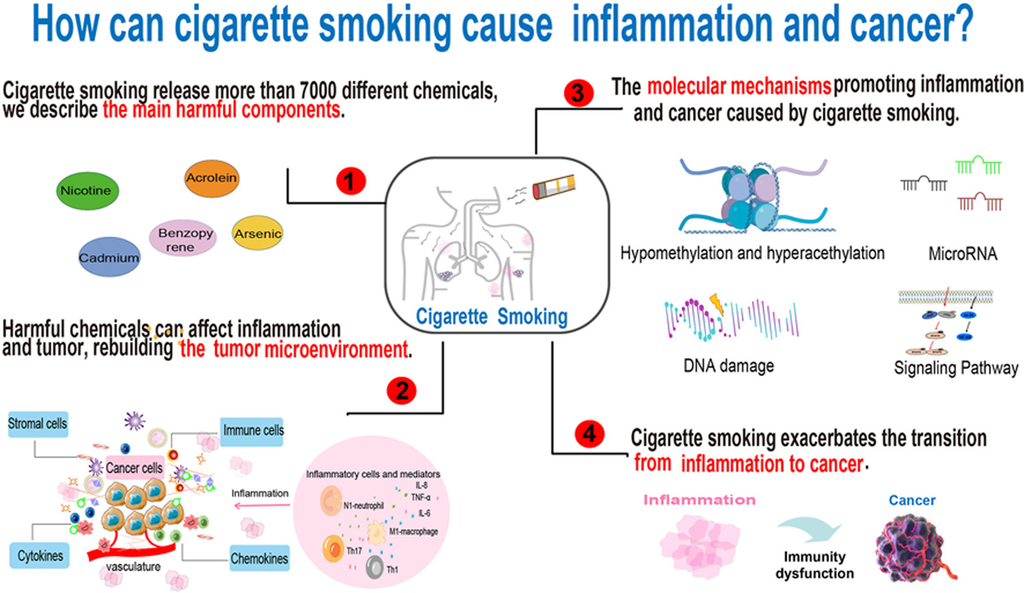

Liu, Yubin, et al. “Dysregulation of immunity by cigarette smoking promotes inflammation and cancer: a review.” Environmental Pollution (2023): 122730

## A Correlação

- É uma comparação de pares de características em uma população. Indica relação.
- É comum assumir que duas coisas relacionadas estão conectadas de forma causal.

**Exemplo**

Correlação anos de estudo e renda – positiva. Podemos dizer que foi a educação que causou a renda?

- Correlação pode ser uma grande coincidência: [Correlação Espúria](https://www.tylervigen.com/spurious-correlations)
- Duas coisas correlacionadas não indicam que possuem uma relação causal.

# Experimento: Fornecendo Respostas

## Resolvendo as questões

- As geleiras na America do Sul estão recuando?
  - Medições cuidadosas de ano para ano devem fornecer a resposta.
- A observação, por si só, não consegue lidar com muitas questões científicas interessantes e importantes.
- **1)** Há aspectos da natureza (ou humana) que não podem ser observados nem direta nem indiretamente.
  - Caso do Neutrino (Wolfgang Pauli, 1932). Subparticula atômica. Não tem carga, quase sem massa, muito pequeno, impossível de observar.

## Resolvendo as questões

- **1)** Há aspectos da natureza (ou humana) que não podem ser observados nem direta nem indiretamente.
  - Caso do Neutrino (Wolfgang Pauli, 1932). Subparticula atômica. Não tem carga, quase sem massa, muito pequeno, impossível de observar.
- **2)** As observações disponíveis são inconclusivas. Radioestesistas que encontram àgua com um graveto.
  - Muitos afirmam que funciona, é um poder uma adivinhação educada?
- **3)** Resolução poderá exigir informações que vão além daquelas fornecidas pela evidência observacional.
- **Formiga e o giz**: não cruzam para não grudar as partículas.
  - **Responde a pergunta?** O fato da formiga se comportar desse jeito não confirma a explicação.

## O Método Científico segundo Richard Feynman

- **Faça uma Observação**
  - Observe um fenômeno no mundo natural.
- **Formule uma Hipótese**
  - Crie uma possível explicação para o fenômeno.
- **Faça Previsões**
  - Preveja o que acontecerá se sua hipótese estiver correta.
- **Teste com Experimentos**
  - Conduza experimentos para testar as previsões.
- **Reavalie a Hipótese**
  - Se os resultados não batem com as previsões, a hipótese está errada.

# Exemplo

## Exemplo do Método Científico:

- **Observação**: Aves migratórias são capazes de navegar por mais de mil quilômetros.
- **Formule uma hipótese**: As aves nascem com essa habilidade?
- **Faça previsões**: Se esse é o caso pássaros na sua primeira migração irão navegar igualmente as aves mais velhas.
- **Experimento**: Um pesquisador movel um grupo de pardais em mais de 1000 km a leste do seu local de origem nos EUA. Os pássaros mais velhos migraram para a direção correta e o mais novos para outra direção.
- **Reavalie a hipótese**.

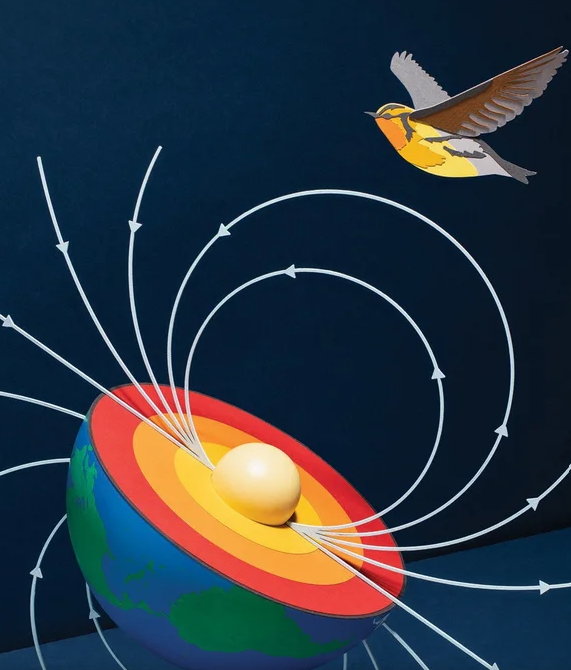

## Confirmação e Rejeição

- Experimentos nem sempre são tão fáceis de projetar e executar
- Existem duas fontes potenciais de erro que podem afetar as descobertas de um experimento.
  - Primeiro, um experimento pode ignorar fatores levando à falsa confirmação.
  - Segundo, ignorar fatores que podem levar a falsa rejeição do experimento.

# Tipos de Estudos e Relações Causais

## A Questão da Causalidade

**Obesidade no Brasil**

No Brasil apresentou um aumento no número de crianças obesas.

- Quais fatores podem ser responsáveis por esse aumento?
  - Alimentação baseada em ultraprocessados?
  - Pouco exercício?
  - Muito tempo de Tela?
  - Algum outro fator?
  - Alguma combinação de fatores?
- Estudos causais são a principal ferramenta pela qual pesquisadores confrontam tais questões.

## As Dificuldade de Encontrar a Causalidade

- O design de estudos causais e a avaliação de seus resultados apresentam uma série de problemas.
  - Numero limitado de sujeitos e falta de validade externa
  - Como garantir que não foi outro fator que influenciou o resultado
  - Muitas vezes não consegue ser feito da maneira devida (dieta e obesidade de crianças)

# Randomização, estudos prospectivos e retrospectivos

## Estudos Causais Randomizados.

- **Os estudos causais**: Randomização.
  - Conjunto de sujeitos que antes do estudo eram muito parecidos.
  - Nenhum havia sido exposto ao agente causal suspeito.
  - Os sujeitos foram aleatoriamente designados para grupos tratamento e de controle.
  - Somente então os sujeitos experimentais foram expostos à causa suspeita.
- **Forma mais rara de estudos nas Ciências Sociais Aplicadas**

## Exemplo: Impacto da Polícia Comunitária no Combate ao Crime

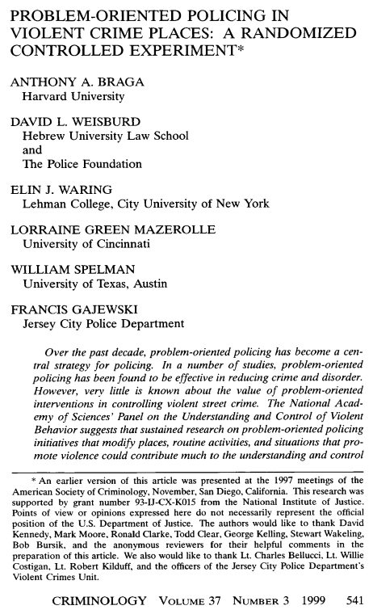

## Estudos Prospectivos.

- Estudos prospectivos começam com sujeitos que já foram expostos ao agente causal sob investigação.
- Observam um grupo ao longo do tempo, começando com um ponto inicial sem conhecimento do resultado.
- O objetivo é identificar como variáveis ao longo do tempo afetam o resultado futuro.

**Exemplo**

Estudos prospectivos começou em 1976 na Harvard Medical School. 122.000 enfermeiros, com idades entre 30 e 55 anos, concordaram em preencher um questionário a cada dois anos sobre doenças e tópicos relacionados à saúde, incluindo tabagismo, uso de hormônios e estado da menopausa.

## Estudos Prospectivos.

- Mesmo os melhores estudos prospectivos se deparam com um grande obstáculo.
- No início de qualquer estudo prospectivo, os sujeitos do grupo experimental já foram expostos ao fator causal suspeito
- É sempre possível que outros fatores causais sejam responsáveis por alguma parte do efeito nos grupos experimental e de controle.
- Pode ser um estudo relacional e não causal.

**Exemplo**

Enfermeiros que tomaram vitamina E tiveram menores taxas de doenças cardíacas. Mas pode ser que aqueles que tomam vitamina E tendam a cuidar bem de si mesmos, praticando exercícios, controlando o peso e comendo uma dieta saudável, todos fatores que contribuem para doenças cardíacas

## Exemplo: Uso de Terapias de Reposição Hormonal e Cancêr de Mama

- **Estudo**: Million Women Study Colaborator. “Breast cancer and hormone-replacement therapy: the Million Women Study (2003)” .
- **Objetivo**: O Million Women Study foi criado para investigar os efeitos de tipos específicos de TRH no câncer de mama incidente e fatal.Foram recrutadas 1.084.110 mulheres do Reino Unido com idades entre 50 e 64 anos para o Million Women Study entre 1996 e 2001.
- **Resultado**: O uso atual de TRH está **associado** a um risco aumentado de câncer de mama incidente e fatal.

[figure not shown]

## Estudos Causais Retrospectivos.

- Iniciam com o resultado final e trabalham de volta para encontrar as causas.
- Identificar fatores que levaram a um resultado específico.
- Estudos retrospectivos começam com dois grupos, controle e tratamento. Caso queira indentificar causalidade…
- Tanto grupo controle como tratamento possuem indivíduos com e sem o efeito analisado.
- Envolve olhar profundo para tentar descobrir os diferentes níveis do fator potencial de causa nos dois grupos.

## Estudos Causais Retrospectivos.

**Exemplo**

Efeitos do chumbo em crianças. Pesquisa com 4.000 crianças de 4 e 15 anos entre 1999 e 2002. Incluiu 135 crianças com transtorno de déficit de atenção e hiperatividade (TDAH). Exames de sangue foram feitos em todas as 4.000.

- As 135 crianças com TDAH apresentaram níveis de chumbo no sangue muito maior do que nas outras crianças.
  - As crianças com TDAH tinham quatro vezes mais probabilidade de ter níveis elevados de chumbo no sangue
- **Questão**: Pode-se concluir que a exposição ao chumbo pode causar TDAH?

## Estudos Causais Retrospectivos.

- Mesmo os melhores estudos retrospectivos podem fornecer apenas evidências fracas para um vínculo causal.
- É extremamente difícil controlar outros fatores causais potenciais.
- Correspondência reversa às vezes é possível em estudos retrospectivos. TDAH -> Chumbo?
  - No estudo crianças com TDAH são mais propensas a comer tinta com chumbo ou inalar pó de tinta por causa de sua hiperatividade.

**Cuidado**

1. Crianças com TDAH tinham “quatro vezes mais probabilidade” de ter níveis elevados de chumbo no sangue.
2. **NÃO PODEMOS CONCLUIR QUE**: Crianças com níveis sanguíneos elevados têm “quatro vezes mais probabilidade” de ter TDAH.

## Exemplo:Há Diferença Remuneratórias por Gênero na Magistratura Brasileira?

- **Estudo** Severi, F.C; Jesus Filho, J. Há diferença remuneratória por gênero na magistratura Brasileira? .
- **Objetivo**: testar a hipótese de que há clara diferença entre as remunerações médias percebidas por juízes e juízas de 8 tribunais de justiça brasileiros.
- **Resultado**: As diferenças nas médias remuneratórias persistem mesmo após o pareamento, o que pode ser explicado pelos mediadores de gênero, que operam gerando melhores oportunidades para homens em desfavor das mulheres.

[figure not shown]